# Exam 1

## Exam 1

#### Metainformation

1. | Tag | Value |
   | --- | --- |
   | `file` | Inferential_Statistics_vufsw-tstatistic-0081-nl_vufsw-tstatistic-0081-nl |
   | `name` | vufsw-tstatistic-0081-nl |
   | `section` | inferential statistics/nhst/test statistic/t statistic |
   | `type` | schoice |
   | `solution` | TRUE, FALSE, FALSE, FALSE |
   | `ID` | c1dbb |
   | `Type` | conceptual |
   | `Program` | NA |
   | `Language` | Dutch |
   | `Level` | statistical reasoning |

#### Question

   De onderzoeker verwacht dat mensen met een migratieachtergrond minder vertrouwen hebben in de politie dan mensen zonder een migratieachtergrond. Zij voert een Independent t-test uit om te achterhalen of dit zo is. De uitkomsten staan hieronder.  
   De onderzoeker toetst éénzijdig met α = 0,05 (alpha =5%). Wat is de conclusie? En waaruit kun je dat opmaken? Kijk in de rij bij “*Equal Variances Assumed*”.

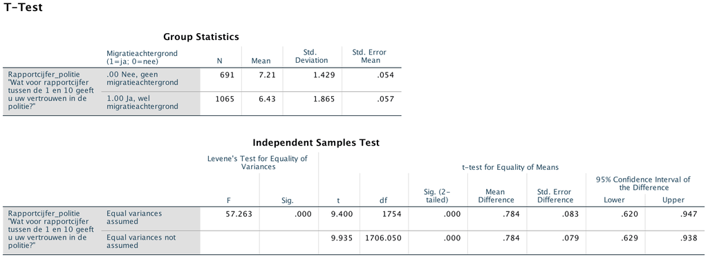

   1. **TRUE:** We **verwerpen** de nulhypothese, want de geobserveerde T-waarde is groter dan de kritieke waarde 1,65.
   2. **FALSE:** We **verwerpen** de nulhypothese, want het geobserveerde verschil tussen de twee gemiddelden (“*Mean Difference*”) is groter dan de kritieke waarde 0,05.
   3. **FALSE:** We kunnen de nulhypothese **niet** verwerpen, want de geobserveerde T-waarde is groter dan de kritieke waarde 1,65.
   4. **FALSE:** We kunnen de nulhypothese **niet** verwerpen, want het geobserveerde verschil tussen de twee gemiddelden (“*Mean Difference*”) is groter dan de kritieke waarde 0,05.

#### Solution

   Language  
   Nederlands

   Levels of Difficulty  
   Easy

   M&T Basics of quantitative research  
   Basics of quantitative research

   M&T BIS  
   Default value
   1. True
   2. False
   3. False
   4. False